# R Reference Guide

for Madison Brady

Fall 2021

Welcome to Madison’s course page for ECO 602/634! Final Project: R Reference Guide

## R Reference Guide

### Loading Data and Packages

1. **install.packages()** is used to install new functions for R
2. **require(name of function)** is used to bring the desired function/a new file into the current working directory, and must be used after installing a package in order to make it work
3. **read.csv(file name on computer)** is used to read a file in csv format from the working directory
4. **library()** can tell you the file path’s name that you are working on, which can then be used with install.packages to tell R exactly where to save a package
5. **here()** is a downloaded function, which must be require()’d in order to use it in your working directory

**example:**

step 1: download a data file into the data folder

step 2: read the data file and download it into an R session:

```r
library(readr)
ginkgo_data_2021 <- read_csv("C:/Users/madis/Desktop/environmental_data - Copy/data/ginkgo_data_2021.csv")
ginkgo <- data.frame(ginkgo_data_2021)
```

### Distribution Functions

**For a discrete parametric distribution, the distribution functions allow you to ask the following questions:**

1. What is the probability that I observe a value of exactly x?: The probability mass function, e.g. dbinom()
2. What is the probability that I observe a value of x or less?: The cumulative mass function, e.g. pbinom()
3. What is the probability that I observe a value of x or more?: The cumulative mass function, e.g. pbinom()
4. What is the median or 50th percentile?: The quantile function, e.g. qbinom()
5. What is the 90th percentile?: The quantile function, e.g. qbinom()

**For a continuous parametric distribution, the distribution functions allow you to ask the following questions:**

1. Is a value of 1.2 or 2.4 more likely? - The probability density function, e.g. dnorm()
2. What is the probability that I observe a value between 1.2 and 2.4?: The cumulative density function, e.g. pnorm()
3. What is the probability that I observe a value of 1.3 or more?: The cumulative density function, e.g. pnorm()
4. What is the probability that I observe a value of 2.4 or less?: The cumulative density function, e.g. pnorm()
5. What is the 20th percentile of fish lengths?: The quantile function, e.g. qnorm()

**Reminder** sum of all probabilities must equal **1**. The answer may be equivalent to 1-pnorm(), etc.

### Data Structures

1. **c()** combines values into a vector or list
2. **length()** gets or sets the length of vectors/lists and factors
3. **matrix()** creates a matrix from a given set of values
4. **data.frame()** create a data frame using existing vectors/lists. Data frames are used as the fundamental data structure by most of R’s modeling software

**examples:**

```r
nrow(ginkgo)
```

```
## [1] 756
```

```r
ncol(ginkgo)
```

```
## [1] 6
```

```r
dim(ginkgo)
```

```
## [1] 756   6
```

Conclusion: the ginkgo data file has 756 rows, 6 columns, and the dimensions 756 cells by 6 cells

### Subsetting

1. **subset()** returns subsets of vectors, matrices or data frames which meet specified conditions (uses Boolean/logical phrases)
2. or use **$** to select a specific column from a data set or data frame:
3. or use **[ ]** to select a subset of data based on row/column:

all rows/columns - df[,]

first row and all columns - df[1,]

first two rows and all columns - df[1:2,]

first and third row and all columns - df[ c(1,3), ]

first row and second and third column - df[1, 2:3]

first and second row and second and third column - df[1:2, 2:3]

**examples:**

```r
petiole <- ginkgo$petiole_length
petiole
```

```
##   [1]  30.00  23.00  20.00  28.00  25.00  55.00  27.00  20.00  50.00  23.00
##  [11]  28.00  26.00  43.00  45.00  42.00  40.00  42.00  40.00  48.00  37.00
##  [21]  50.00  35.00  47.00  23.00  21.00  25.00  41.00  78.00  88.00  38.00
##  [31]  59.00  85.00  42.00  73.00  56.00  76.00  94.00  57.00  30.00  28.00
##  [41]  80.00  58.00  70.00  64.00  43.00  58.00  49.00  35.00  72.00  88.00
##  [51]  63.00  55.00  56.00  54.00  49.00  28.00  57.00  53.00  51.00  80.00
##  [61]  42.00  49.00  49.00  36.00  33.00  46.00  59.00  41.00  58.00  96.00
##  [71]  58.00  45.00  34.00  35.00  59.00  78.00  78.00  41.00  75.00  41.00
##  [81]  30.00  23.00  20.00  28.00  25.00  55.00  27.00  20.00  50.00  23.00
##  [91]  28.00  26.00  43.00  45.00  42.00  40.00  42.00  40.00  48.00  37.00
## [101]  50.00  35.00  47.00  23.00  21.00  25.00  41.00  57.00  40.00  25.00
## [111]  38.00  48.00  48.00  53.00  52.00  52.00  51.00  65.00  48.00  88.00
## [121]  25.00  33.00  68.00  45.00  55.00  51.00  61.00  30.00  37.00  50.00
## [131]  72.00  31.00  54.00  27.00  32.00  59.00  48.00  54.00  93.00  54.00
## [141]  43.00  42.00  14.00  27.00  70.00  58.00  48.00  60.00  52.00  55.00
```

[output cut: 61 more lines]

```r
library(readr)
penguins <- read_csv("C:/Users/madis/Desktop/environmental_data - Copy/data/penguins.csv")
Adelie <- subset(penguins, species == "Adelie")
Adelie
```

```
## # A tibble: 152 x 8
##    species island    bill_length_mm bill_depth_mm flipper_length_mm body_mass_g
##    <chr>   <chr>              <dbl>         <dbl>             <dbl>       <dbl>
##  1 Adelie  Torgersen           39.1          18.7               181        3750
##  2 Adelie  Torgersen           39.5          17.4               186        3800
##  3 Adelie  Torgersen           40.3          18                 195        3250
##  4 Adelie  Torgersen           NA            NA                  NA          NA
##  5 Adelie  Torgersen           36.7          19.3               193        3450
##  6 Adelie  Torgersen           39.3          20.6               190        3650
##  7 Adelie  Torgersen           38.9          17.8               181        3625
##  8 Adelie  Torgersen           39.2          19.6               195        4675
##  9 Adelie  Torgersen           34.1          18.1               193        3475
## 10 Adelie  Torgersen           42            20.2               190        4250
## # ... with 142 more rows, and 2 more variables: sex <chr>, year <dbl>
```

```r
first.row.all.columns <- ginkgo[1,]
first.row.all.columns
```

```
##   site_id seeds_present max_width max_depth notch_depth petiole_length
## 1    7719         FALSE        71        40           0             30
```

```r
row.2.column.3 <- ginkgo[2,3]
row.2.column.3
```

```
## [1] 64
```

```r
all.rows.column.3 <- ginkgo[,3]
all.rows.column.3
```

```
##   [1]  71.0  64.0  55.0  62.0  65.0  70.0  63.0  56.0  51.0  57.0  59.0  63.0
##  [13]  70.0  50.0  56.0  46.0  54.0  62.0  56.0  55.0  59.0  60.0  63.0  61.0
##  [25]  58.0  55.0  53.0  81.0  94.0  75.0  82.0  86.0  79.0  93.0  88.0  76.0
##  [37]  71.0  91.0  71.0  82.0  65.0  83.0  73.0 102.0  78.0  88.0  81.0  70.0
##  [49]  80.0  96.0  80.0  82.0  86.0  87.0  89.0  69.0  93.0  98.0  81.0  79.0
##  [61]  82.0  85.0  81.0  59.0  53.0  83.0  80.0  77.0  81.0  76.0  82.0  81.0
##  [73]  77.0  68.0  41.0  70.0  68.0  80.0  89.0  90.0  71.0  64.0  55.0  62.0
##  [85]  65.0  70.0  63.0  56.0  51.0  57.0  59.0  63.0  70.0  50.0  56.0  46.0
##  [97]  54.0  62.0  56.0  55.0  59.0  60.0  63.0  61.0  58.0  55.0  53.0  77.0
## [109]  72.0  57.0  75.0  75.0  75.0  67.0  74.0  71.0  72.0  55.0  77.0  97.0
## [121]  73.0  64.0  69.0  92.0  64.0  68.0  53.0  97.0 100.0  90.0  89.0  59.0
## [133]  97.0  76.0  85.0  90.0  87.0  85.0  80.0  86.0  89.0  84.0  88.0  80.0
## [145] 102.0  94.0  95.0 109.0  84.0  68.0  59.0  74.0  70.0  71.0  69.0  74.0
## [157]  70.0  78.0  87.0  69.0  60.0  72.0  59.0  75.0  81.0  82.0  74.0  72.0
## [169]  79.0  84.0  75.0  72.0  88.0  80.0  90.0  58.0  61.0  95.0  72.0  90.0
```

[output cut: 48 more lines]

### Numerical Data Exploration

1. **summary()** - prints a results summary
2. **mean()** - prints out the mean of a vector
3. **sd()** - prints out the standard deviation of a vector

**examples**

```r
summary(ginkgo)
```

```
##     site_id      seeds_present     max_width        max_depth
##  Min.   : 1896   Mode :logical   Min.   : 16.00   Min.   : 19.00
##  1st Qu.: 3703   FALSE:636       1st Qu.: 63.00   1st Qu.: 43.00
##  Median : 6066   TRUE :120       Median : 74.00   Median : 51.00
##  Mean   : 6079                   Mean   : 74.34   Mean   : 58.51
##  3rd Qu.: 7206                   3rd Qu.: 85.00   3rd Qu.: 66.00
##  Max.   :12982                   Max.   :130.00   Max.   :145.00
##
##   notch_depth    petiole_length
##  Min.   : 0.00   Min.   :  8.00
##  1st Qu.: 0.00   1st Qu.: 34.00
##  Median : 0.00   Median : 47.00
##  Mean   : 2.99   Mean   : 48.25
##  3rd Qu.: 4.00   3rd Qu.: 60.00
##  Max.   :49.00   Max.   :113.00
##                  NA's   :4
```

```r
mean(na.omit(petiole))
```

```
## [1] 48.2515
```

```r
sd(na.omit(petiole))
```

```
## [1] 18.58855
```

### Graphical Data Exploration

1. **par(mfrow = c(1,2))** is a function that tells the plot window in R how to arrange a series of figures. In this instance, **c(1,2)** asks for a plot window with 2 figures arranged in **1 row** with **2 columns**
2. **plot()** required arguments:

col = color of points

pch = type of point indicated by a number (Google to see a key)

cex = magnification extent in relation to default sizing

main = title (must be in quotes)

sub = subtitle (must be in quotes)

xlab = x axis label (must be in quotes)

ylab = y axis label (must be in quotes)

xlim = max value for x axis

ylim = max value for y axis

type = “p” for point (default), “l” for line, “b” for both

to add a line, use abline() or use plot() again with the added specification that add = TRUE

3. **hist()** required arguments are mostly same as plot() function, with the addition of:

breaks = numeric, indicates distance between bars/placement on the x axis

4. **boxplot()** required arguments are mostly the same as plot() function, with the addition of:

boxplot = subset ~ subset, data set to specify how data is organized into different boxes

**examples:**

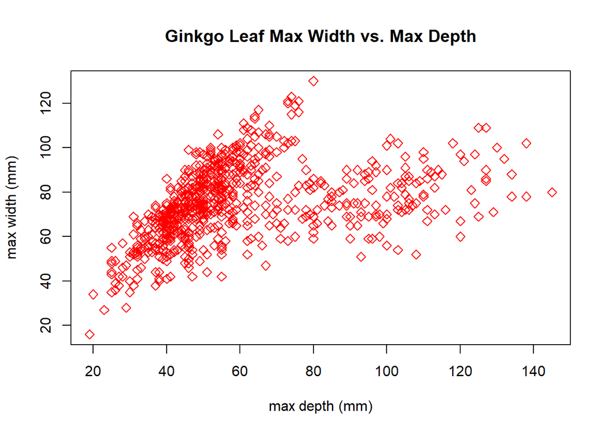

```r
plot(ginkgo$max_depth, ginkgo$max_width, main = "Ginkgo Leaf Max Width vs. Max Depth", xlab = "max depth (mm)", ylab = "max width (mm)", pch = 5, type = "p", col = "red")
```

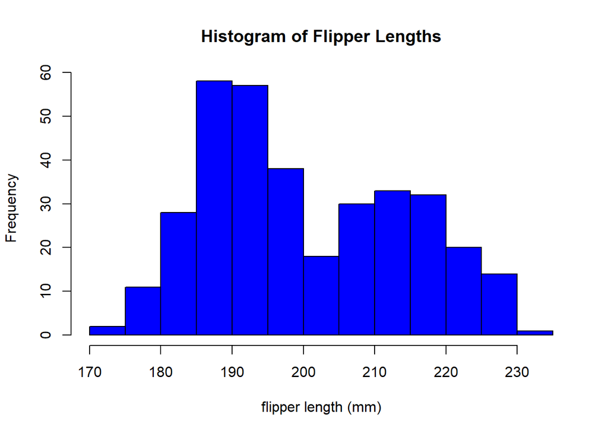

```r
hist(penguins$flipper_length_mm, main = "Histogram of Flipper Lengths", xlab = "flipper length (mm)", ylab = "Frequency", col = "blue")
```

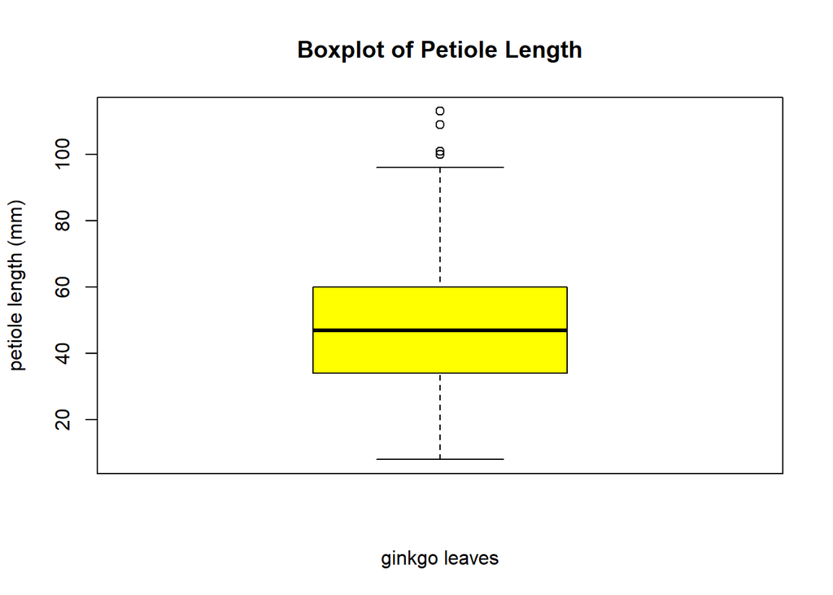

```r
boxplot(ginkgo$petiole_length, main = "Boxplot of Petiole Length", xlab = "ginkgo leaves", ylab = "petiole length (mm)", col = "yellow")
```

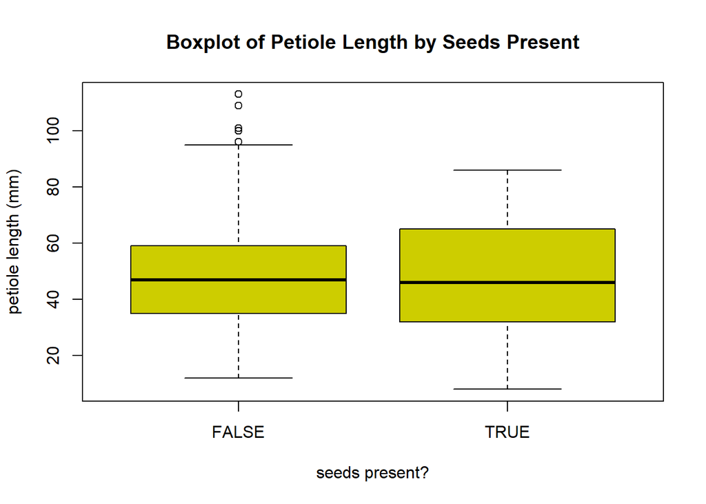

```r
boxplot(petiole_length ~ seeds_present, data = ginkgo, main = "Boxplot of Petiole Length by Seeds Present", xlab = "seeds present?", ylab = "petiole length (mm)", col = "yellow3")
```

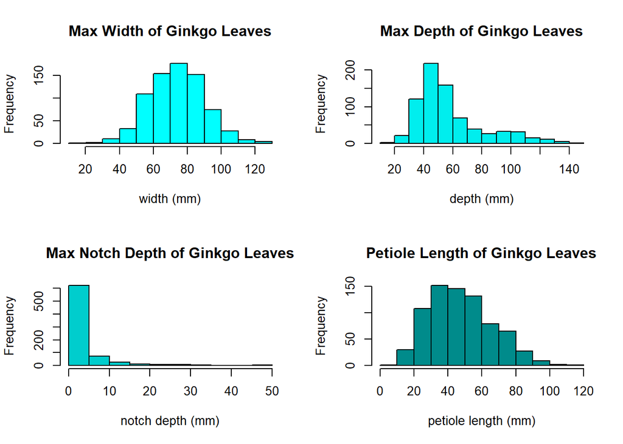

```r
par(mfrow = c(2,2))
hist(ginkgo$max_width, main = "Max Width of Ginkgo Leaves", xlab = "width (mm)", col = "cyan1")
hist(ginkgo$max_depth, main = "Max Depth of Ginkgo Leaves", xlab = "depth (mm)", col = "cyan2")
hist(ginkgo$notch_depth, main = "Max Notch Depth of Ginkgo Leaves", xlab = "notch depth (mm)", col = "cyan3")
hist(ginkgo$petiole_length, main = "Petiole Length of Ginkgo Leaves", xlab = "petiole length (mm)", col = "cyan4")
```